# Processing MA Results

Lukas

2024-09-06

# Disclaimer

The following R code was developed with the assistance of AI tools. Specifically, the ChatGPT-4o model was employed to optimise the code, provide solutions, and implement adjustments. The code segments were iteratively refined and reviewed to ensure they performed the intended functions. Additionally, key results were recalculated using tools like Jamovi to verify their accuracy.

The use of ChatGPT offered significant advantages, particularly in terms of speed and adaptability in generating code. It served as a valuable resource by translating human language into programming language. However, several challenges arose during this process. Firstly, ChatGPT occasionally generated incorrect or non-functional code. Secondly, its solutions often involved more complex or less efficient code variants, which sometimes introduced additional variables or unnecessary nesting. This approach frequently disregarded programming best practices, thereby reducing the clarity and transparency of the code.

It should be noted, however, that similar issues—such as reduced code quality and comprehensibility—can also arise when using examples from online forums. As such, the ultimate responsibility for the correctness, completeness, and application of the code rests solely with the author.

## Prompt examples

Example 1: Variable Cleaning and Type Conversion Task: Clean the following variables by formatting their column names as if they were processed with the janitor package (all lowercase). Write the code to convert all these variables into numeric types. If a cell does not contain a numeric value, set it to “exclude.”

Variables: PreDCP_1_TEXT, PapDCP_1_TEXT, S_PRE_IV, S_Pre_DV, S_Pre_DCP, S_Pre_SMU, S_Pre_SIC, S_Pap_IV, S_Pap_DV, S_Pap_DCP, S_Pap_SMU, S_Pap_SIC, Prompt version a Strictness PREREG, Prompt version aStrictness Pubstud, Con_IV, Con_DV, Con_DCP, Con_SMU, Con_SIC, Global_Consistency_Esimate.

Example 2: Creating a New Dataset and Renaming Values Task: Create a new dataset data_results_finito based on the dataset data_results_filtered_clean_exclude_numeric.

In the column prompt_version, rename the values “v4” and “V4” to “D.” Add a new column master_exclude. Set its value to “include” for all rows, except for rows where the column date_gpt has an NA. In these cases, set the value to “exclude.”

Example 3: Renaming and Cleaning Columns Task: Clean the following column names by converting them to lowercase as if they were processed with the janitor package: PSP, Coder, PrePreMI1, PreMI1, PreIV1, CPreIV1, PreNIV1_1, PreNIV1_2, PreNIV1_3, PrePreMI2, PreMI2, PreIV2, CPreIV2, PreNIV2_1, PreNIV2_2, PreNIV2_3.

Apply these changes to the dataset data_olmo_raw_selected.

Example 4: Overview of Column Types Task: Is there a command in R that provides an overview of which variables in a dataset are stored as character and which are stored as numeric? Write the code to accomplish this task.

Example 5: Conditional Transformation of NA Values Task: Mutate the dataset data_olmo_raw_selected_mutated to replace missing values (NA) in the variables pre_pre_mi1, pre_mi1, pre_iv1, c_pre_iv1, pre_niv1_1, pre_niv1_2, pre_niv1_3 under the following conditions:

If pre_niv1_3 = “No, none of the elements”, set the NA values in pre_niv1_1 and pre_niv1_2 to “n.” If either pre_niv1_1 or pre_niv1_2 contains the value “y,” set the NA values in the other variable to “n.” Otherwise, replace all remaining NA values with “x.”

Example 6: Refined Exception Handling Task: If only one of the two columns pre_niv1_1 or pre_niv1_2 contains the value “y,” replace the missing values (NA) in the other column with “n.” Ensure that no other conditions are overwritten by this logic.

Example 7: Step-by-Step Code Explanation Task: Explain the following code line by line. Describe what each line does and why it is necessary:…

# Dependencies

```r
library(tidyverse)
library("readxl")
library(janitor)
library(stringr)
library(openxlsx)
```

# Clean GPT testdata

## Read GPT data

```r
data_gpt_raw <- read_excel("../Data/raw/DATA_Resultate_raw.xlsx") |>
  janitor::clean_names()
data_gpt_new <- read_excel("../Data/raw/DATA_Resultate_neu.xlsx") |>
  janitor::clean_names()
```

##select and remove unwanted columns

```r
data_gpt_filtered <- data_gpt_raw %>%
  select(
    -prereg_vorhanden,
    -paper_vorhanden,
    -gpt_link_extraction,
    -gpt_link_comparison,
    -notes_extraction,
    -notes_comparison,
    -hyp_pre,
    -hyp_pap,
    -type,
    -iv1,
    -iv2,
    -tv,
    -dv,
    -fcv,
    -ocv,
    -starts_with("x")
    )


data_gpt_new_filtered <- data_gpt_new %>%
  select(
    -prereg_vorhanden,
    -paper_vorhanden,
    -gpt_link_extraction,
    -gpt_link_comparison,
    -notes_extraction,
    -notes_comparison,
    -hyp_pre,
    -hyp_pap,
    -type,
    -iv1,
    -iv2,
    -tv,
    -dv,
    -fcv,
    -ocv,
    -starts_with("x")
    )
```

## kategorien alphabetic säubern

```r
gpt_categories_alphabetic <- c("pre_pre_mi1", "pre_mi1", "pre_iv1", "c_pre_iv1", "pre_niv1_1", "pre_niv1_2",
                            "pre_pre_mi2", "pre_mi2", "pre_iv2", "c_pre_iv2", "pre_niv2_1", "pre_niv2_2",
                            "pre_pre_mt", "pre_mt", "pre_tv", "c_pre_tv", "pre_ntv_1", "pre_ntv_2",
                            "pre_dv", "c_pre_dv", "pre_ndv_1", "pre_ndv_2",
                            "pre_pre_mc", "pre_mc", "pre_cv", "c_pre_cv", "pre_ncv_1", "pre_ncv_2",
                            "pre_dcp_1", "pre_dcp_2", "pre_pa", "pre_iec_1", "pre_imd_1", "pre_imd_2",
                            "pre_sm_1", "pre_sm_2", "pre_sm_3",
                            "pre_vsa_1", "pre_vsa_2", "pre_vsa_3", "pre_ic", "pap_pap_mi1", "pap_mi1",
                            "pap_iv1", "c_pap_iv1", "pap_niv1_1", "pap_niv1_2", "pap_pap_mi2", "pap_mi2",
                            "pap_iv2", "c_pap_iv2", "pap_niv2_1", "pap_niv2_2", "pap_pap_mt", "pap_mt",
                            "pap_tv", "c_pap_tv", "pap_ntv_1", "pap_ntv_2", "pap_dv", "c_pap_dv",
                            "pap_ndv_1", "pap_ndv_2", "pap_pap_mc", "pap_mc", "pap_cv", "c_pap_cv",
                            "pap_ncv_1", "pap_ncv_2", "pap_dcp_1", "pap_dcp_2", "pap_pa", "pap_iec_1",
                            "pap_imd_1", "pap_imd_2", "pap_sm_1", "pap_sm_2", "pap_sm_3", "pap_vsa_1",
                            "pap_vsa_2", "pap_vsa_3", "pap_ic", "match_mi1", "match_iv1_0", "match_iv1_1",
                            "match_iv1_2", "match_iv1_3", "match_mi2", "match_iv2_0", "match_iv2_1",
                            "match_iv2_2", "match_iv2_3", "match_mt", "match_tv_0", "match_tv_1",
                            "match_tv_2", "match_tv_3", "match_dv_0", "match_dv_1", "match_dv_2",
                            "match_dv_3", "match_mc", "match_cv_0", "match_cv_1", "match_cv_2",
                            "match_cv_3", "match_dcp_1", "match_dcp_2", "match_iec_1", "match_imd_1",
                            "match_imd_2",  "match_sm_1", "match_sm_2", "match_sm_3", "match_vsa_1",
                            "match_vsa_2", "match_vsa_3", "match_ic")

#for gpt
gpt_frequencies_categories <- lapply(data_gpt_filtered[gpt_categories_alphabetic], table)

#for new vE
gpt_new_frequencies_categories <- lapply(data_gpt_new_filtered[gpt_categories_alphabetic], table)


#frequencies_categories



clean_value <- function(x) {
  cleaned <- tolower(x)
  cleaned <- gsub("yy", "y", cleaned)
  cleaned <- gsub("xx", "x", cleaned)
  cleaned <- gsub("nn", "n", cleaned)
  return(cleaned)
}

#for raw
data_gpt_filtered_clean <- data_gpt_filtered %>%
  mutate_at(vars(one_of(gpt_categories_alphabetic)), clean_value)

gpt_frequencies_categories_cleaned <- lapply(data_gpt_filtered_clean[gpt_categories_alphabetic], table)

#for new

data_gpt_new_filtered_clean <- data_gpt_new_filtered %>%
  mutate_at(vars(one_of(gpt_categories_alphabetic)), clean_value)

gpt_new_frequencies_categories_cleaned <- lapply(data_gpt_new_filtered_clean[gpt_categories_alphabetic], table)

#gpt_frequencies_categories_cleaned

#gpt_new_frequencies_categories_cleaned



replace_with_exclude <- function(x) {
  ifelse(x %in% c("x", "y", "n"), x, "exclude")
}

#gpt
data_gpt_filtered_clean_exclude <- data_gpt_filtered_clean %>%
  mutate_at(vars(one_of(gpt_categories_alphabetic)), replace_with_exclude)

#new
data_gpt_new_filtered_clean_exclude <- data_gpt_new_filtered_clean %>%
  mutate_at(vars(one_of(gpt_categories_alphabetic)), replace_with_exclude)


# Check gpt frequencies after cleaning
gpt_frequencies_categories_cleaned_exclude <- lapply(data_gpt_filtered_clean_exclude[gpt_categories_alphabetic], table)

# Check new frequencies after cleaning
gpt_new_frequencies_categories_cleaned_exclude <- lapply(data_gpt_new_filtered_clean_exclude[gpt_categories_alphabetic], table)


#gpt_frequencies_categories_cleaned_exclude

#gpt_new_frequencies_categories_cleaned_exclude
```

## kategorien numeric säubern

```r
# List of column names that need to be converted to numeric
gpt_categories_numeric <- c("pre_dcp_1_text", "pap_dcp_1_text", "s_pre_iv", "s_pre_dv",
                        "s_pre_dcp", "s_pre_smu", "s_pre_sic", "s_pap_iv", "s_pap_dv",
                        "s_pap_dcp", "s_pap_smu", "s_pap_sic", "prompt_version_a_strictness_prereg",
                        "prompt_version_a_strictness_pubstud", "con_iv", "con_dv",
                        "con_dcp", "con_smu", "con_sic", "global_consistency_esimate")

# Convert gpt to numeric and replace non-numeric with 'exclude'
data_gpt_filtered_clean_exclude_numeric <- data_gpt_filtered_clean_exclude %>%
  mutate_at(vars(one_of(gpt_categories_numeric)),
            ~ifelse(is.na(as.numeric(.)), "exclude", as.numeric(.)))
# Convert new to numeric and replace non-numeric with 'exclude'
data_gpt_new_filtered_clean_exclude_numeric <- data_gpt_new_filtered_clean_exclude %>%
  mutate_at(vars(one_of(gpt_categories_numeric)),
            ~ifelse(is.na(as.numeric(.)), "exclude", as.numeric(.)))
#gpt
# Check frequencies after cleaning
gpt_frequencies_categories_cleaned_exclude_numeric <- lapply(data_gpt_filtered_clean_exclude_numeric[gpt_categories_numeric], table)

#gpt_frequencies_categories_cleaned_exclude_numeric

#new
# Check new frequencies after cleaning
gpt_new_frequencies_categories_cleaned_exclude_numeric <- lapply(data_gpt_new_filtered_clean_exclude_numeric[gpt_categories_numeric], table)

#gpt_new_frequencies_categories_cleaned_exclude_numeric
```

## finish data_gpt_finito

```r
#for gpt

# Ändere die Werte "v4" und "V4" in der Spalte prompt_version zu "D"
data_gpt_finito <- data_gpt_filtered_clean_exclude_numeric %>%
  mutate(prompt_version = ifelse(prompt_version %in% c("v4", "V4"), "D", prompt_version))

# Neue Spalte master_exclude hinzufügen und standardmäßig auf "include" setzen
data_gpt_finito <- data_gpt_finito %>%
  mutate(master_exclude = ifelse(is.na(date_gpt), "exclude", "include"))

#for new
# Ändere die Werte "v4" und "V4" in der Spalte prompt_version zu "D"
data_gpt_new_finito <- data_gpt_new_filtered_clean_exclude_numeric %>%
  mutate(prompt_version = ifelse(prompt_version %in% c("v4", "V4"), "D", prompt_version))

# Neue Spalte master_exclude hinzufügen und standardmäßig auf "include" setzen
data_gpt_new_finito <- data_gpt_new_finito %>%
  mutate(master_exclude = ifelse(is.na(date_gpt), "exclude", "include"))


# Erstellen des neuen Datensatzes
data_gpt_ve <- data_gpt_new_finito %>%
  # Filtern nach Zeilen, bei denen die Spalte 'prompt_version' den Wert 'E' hat
  filter(prompt_version == "E") %>%
  # Auswahl der gewünschten Spalten
  select(psp, title_pap, study_pap, date_gpt, prompt_version, test_retest,
         deviation_text_new, master_exclude, match_dv_0, match_dv_1,
         match_dv_2, match_dv_3, match_dcp_1, match_dcp_2,
         match_sm_1, match_sm_2, match_sm_3)

# Optional: Überprüfung der ersten Zeilen des neuen Datensatzes
head(data_gpt_ve)
```

```
## # A tibble: 6 × 17
##     psp title_pap       study_pap date_gpt            prompt_version test_retest
##   <dbl> <chr>           <chr>     <dttm>              <chr>          <chr>
## 1   411 The power of m… Study 2   2024-09-30 00:00:00 E              Test
## 2   412 The Primacy Ef… Experime… 2024-09-30 00:00:00 E              Test
## 3   413 The Primacy Ef… Experime… 2024-09-30 00:00:00 E              Test
## 4   417 The relative c… NA        2024-09-30 00:00:00 E              Test
## 5   418 The role of em… Study 2   2024-09-30 00:00:00 E              Test
## 6   419 The Role of Ex… Experime… 2024-09-30 00:00:00 E              Test
## # ℹ 11 more variables: deviation_text_new <chr>, master_exclude <chr>,
## #   match_dv_0 <chr>, match_dv_1 <chr>, match_dv_2 <chr>, match_dv_3 <chr>,
## #   match_dcp_1 <chr>, match_dcp_2 <chr>, match_sm_1 <chr>, match_sm_2 <chr>,
## #   match_sm_3 <chr>
```

# Clean olmos data

## read olmos data

```r
DATA_olmo_raw <- read_excel("../data/raw/Data Preregistration Effectiveness.xlsx") |>
  janitor::clean_names()
data_olmo_raw <- DATA_olmo_raw[seq(3, nrow(DATA_olmo_raw), 3), ] # select only reconciled data


#rename  so that "pre_iec", "pap_iec and "match_iec" colum in olmo are also called pre_iec_1`, `pap_iec_1`, and `match_iec_1` like gpt
data_olmo_raw <- data_olmo_raw %>%
  rename(
    pre_iec_1 = pre_iec,
    pap_iec_1 = pap_iec,
    match_iec_1 = match_iec
  )
```

## select only wanted colums

```r
olmo_selected_columns <- c(
  "psp",  "coder", "type" ,"pre_pre_mi1", "pre_mi1", "pre_iv1", "c_pre_iv1", "pre_niv1_1",
  "pre_niv1_2", "pre_niv1_3", "pre_pre_mi2", "pre_mi2", "pre_iv2", "c_pre_iv2",
  "pre_niv2_1", "pre_niv2_2", "pre_niv2_3", "pre_pre_mt", "pre_mt", "pre_tv",
  "c_pre_tv", "pre_ntv_1", "pre_ntv_2", "pre_ntv_3", "pre_dv", "c_pre_dv",
  "pre_ndv_1", "pre_ndv_2", "pre_ndv_3", "pre_pre_mc", "pre_mc", "pre_cv",
  "c_pre_cv", "pre_ncv_1", "pre_ncv_2", "pre_ncv_3", "pre_dcp_1", "pre_dcp_2",
  "pre_dcp_3", "pre_dcp_1_text", "pre_pa", "pre_iec_1",
  "pre_imd_1", "pre_imd_2", "pre_imd_3",
  "pre_sm_1", "pre_sm_2", "pre_sm_3", "pre_sm_4", "pre_vsa_1", "pre_vsa_2",
  "pre_vsa_3", "pre_vsa_4", "pre_ic", "pap_pap_mi1", "pap_mi1", "pap_iv1", "c_pap_iv1",
  "pap_niv1_1", "pap_niv1_2", "pap_niv1_3", "pap_pap_mi2", "pap_mi2", "pap_iv2",
  "c_pap_iv2", "pap_niv2_1", "pap_niv2_2", "pap_niv2_3", "pap_pap_mt", "pap_mt",
  "pap_tv", "c_pap_tv", "pap_ntv_1", "pap_ntv_2", "pap_ntv_3", "pap_dv", "c_pap_dv",
  "pap_ndv_1", "pap_ndv_2", "pap_ndv_3", "pap_pap_mc", "pap_mc", "pap_cv", "c_pap_cv",
  "pap_ncv_1", "pap_ncv_2", "pap_ncv_3", "pap_dcp_1", "pap_dcp_2", "pap_dcp_3",
  "pap_dcp_1_text", "pap_pa", "pap_iec_1",
  "pap_imd_1", "pap_imd_2", "pap_imd_3", "pap_sm_1",
  "pap_sm_2", "pap_sm_3", "pap_sm_4", "pap_vsa_1", "pap_vsa_2", "pap_vsa_3",
  "pap_vsa_4", "pap_ic", "match_mi1", "match_iv1_0", "match_iv1_1", "match_iv1_2",
  "match_iv1_3", "match_iv1_4", "match_mi2", "match_iv2_0", "match_iv2_1",
  "match_iv2_2", "match_iv2_3", "match_iv2_4", "match_mt", "match_tv_0",
  "match_tv_1", "match_tv_2", "match_tv_3", "match_tv_4", "match_dv_0", "match_dv_1",
  "match_dv_2", "match_dv_3", "match_dv_4", "match_mc", "match_cv_0", "match_cv_1",
  "match_cv_2", "match_cv_3", "match_cv_4", "match_dcp_1", "match_dcp_2",
  "match_dcp_3", "match_iec_1",
  "match_imd_1", "match_imd_2", "match_imd_3","match_sm_1",
  "match_sm_2", "match_sm_3", "match_sm_4", "match_vsa_1", "match_vsa_2",
  "match_vsa_3", "match_vsa_4", "match_ic"
)


data_olmo_raw_selected <- data_olmo_raw %>%
  select(all_of(olmo_selected_columns))
```

## mutate olmo answers

### renaming

```r
# Liste der Datentypen aller Variablen
sapply(data_olmo_raw_selected, class)
```

```
##            psp          coder           type    pre_pre_mi1        pre_mi1
##      "numeric"    "character"    "character"    "character"    "character"
##        pre_iv1      c_pre_iv1     pre_niv1_1     pre_niv1_2     pre_niv1_3
##    "character"    "character"    "character"    "character"    "character"
##    pre_pre_mi2        pre_mi2        pre_iv2      c_pre_iv2     pre_niv2_1
##    "character"    "character"    "character"    "character"    "character"
##     pre_niv2_2     pre_niv2_3     pre_pre_mt         pre_mt         pre_tv
##    "character"    "character"    "character"    "character"    "character"
##       c_pre_tv      pre_ntv_1      pre_ntv_2      pre_ntv_3         pre_dv
##    "character"    "character"    "character"    "character"    "character"
##       c_pre_dv      pre_ndv_1      pre_ndv_2      pre_ndv_3     pre_pre_mc
##    "character"    "character"    "character"    "character"    "character"
##         pre_mc         pre_cv       c_pre_cv      pre_ncv_1      pre_ncv_2
##    "character"    "character"    "character"    "character"    "character"
##      pre_ncv_3      pre_dcp_1      pre_dcp_2      pre_dcp_3 pre_dcp_1_text
##    "character"    "character"    "character"    "character"    "character"
##         pre_pa      pre_iec_1      pre_imd_1      pre_imd_2      pre_imd_3
##    "character"    "character"    "character"    "character"    "character"
##       pre_sm_1       pre_sm_2       pre_sm_3       pre_sm_4      pre_vsa_1
##    "character"    "character"    "character"    "character"    "character"
##      pre_vsa_2      pre_vsa_3      pre_vsa_4         pre_ic    pap_pap_mi1
##    "character"    "character"    "character"    "character"    "character"
##        pap_mi1        pap_iv1      c_pap_iv1     pap_niv1_1     pap_niv1_2
##    "character"    "character"    "character"    "character"    "character"
##     pap_niv1_3    pap_pap_mi2        pap_mi2        pap_iv2      c_pap_iv2
##    "character"    "character"    "character"    "character"    "character"
##     pap_niv2_1     pap_niv2_2     pap_niv2_3     pap_pap_mt         pap_mt
##    "character"    "character"    "character"    "character"    "character"
##         pap_tv       c_pap_tv      pap_ntv_1      pap_ntv_2      pap_ntv_3
##    "character"    "character"    "character"    "character"      "logical"
##         pap_dv       c_pap_dv      pap_ndv_1      pap_ndv_2      pap_ndv_3
##    "character"    "character"    "character"    "character"    "character"
##     pap_pap_mc         pap_mc         pap_cv       c_pap_cv      pap_ncv_1
##    "character"    "character"    "character"    "character"    "character"
##      pap_ncv_2      pap_ncv_3      pap_dcp_1      pap_dcp_2      pap_dcp_3
##    "character"    "character"    "character"    "character"    "character"
## pap_dcp_1_text         pap_pa      pap_iec_1      pap_imd_1      pap_imd_2
##    "character"    "character"    "character"    "character"    "character"
##      pap_imd_3       pap_sm_1       pap_sm_2       pap_sm_3       pap_sm_4
##    "character"    "character"    "character"    "character"    "character"
##      pap_vsa_1      pap_vsa_2      pap_vsa_3      pap_vsa_4         pap_ic
##    "character"    "character"    "character"    "character"    "character"
##      match_mi1    match_iv1_0    match_iv1_1    match_iv1_2    match_iv1_3
##    "character"    "character"    "character"    "character"    "character"
##    match_iv1_4      match_mi2    match_iv2_0    match_iv2_1    match_iv2_2
##    "character"    "character"    "character"    "character"    "character"
##    match_iv2_3    match_iv2_4       match_mt     match_tv_0     match_tv_1
##    "character"    "character"    "character"    "character"    "character"
##     match_tv_2     match_tv_3     match_tv_4     match_dv_0     match_dv_1
##    "character"    "character"    "character"    "character"    "character"
##     match_dv_2     match_dv_3     match_dv_4       match_mc     match_cv_0
##    "character"    "character"    "character"    "character"    "character"
##     match_cv_1     match_cv_2     match_cv_3     match_cv_4    match_dcp_1
##    "character"    "character"    "character"    "character"    "character"
##    match_dcp_2    match_dcp_3    match_iec_1    match_imd_1    match_imd_2
##    "character"    "character"    "character"    "character"    "character"
##    match_imd_3     match_sm_1     match_sm_2     match_sm_3     match_sm_4
##    "character"    "character"    "character"    "character"    "character"
##    match_vsa_1    match_vsa_2    match_vsa_3    match_vsa_4       match_ic
##    "character"    "character"    "character"      "logical"    "character"
```

```r
data_olmo_selected_mutated <- data_olmo_raw_selected %>%
  mutate_if(is.character, ~ case_when(
    . == "No" ~ "n",
    . == "Yes" ~ "y",
    . == "Composite" ~ "y",
    . == "Non-composite" ~ "n",
    . == "Non-Composite" ~ "n",
    . == "Yes, procedure" ~ "y",
    . == "Yes, values" ~ "y",
    . == "Yes, sample size" ~ "y",
    . == "Yes, sampling frame" ~ "y",
    . == "Yes, definition" ~ "y",
    . == "Yes, model" ~ "y",
    . == "Yes, variables" ~ "y",
    . == "Yes, details" ~ "y",
    . == "Yes, which" ~ "y",
    . == "Yes, how" ~ "y",
    . == "Yes, deal" ~ "y",
    . == "Yes, specification" ~ "y",
    . == "Yes, construction" ~ "y",
    . == "Yes, method" ~ "y",
    TRUE ~ .
  ))
```

### 2 possibilities

for defining what counts as an x (because an answer is not applicable) or as an “n” there are many dependencies to account for, and two main possibilities:

1. desribe all dependencies:
- if pre_pre_mi1 = n then NA of pre_mi1 -> x
- if pre_pre_mi1 = y then NA of pre_iv1, c_pre_iv1, pre_niv1_1, pre_niv1_2, pre_niv1_3 -> x
- if pre_pre_mi1 = n & c_pre_iv1 = y then NA of pre_niv1_1, pre_niv1_2, pre_niv1_3 -> x
- if pre_iv1 = n then NA of c_pre_iv1, pre_niv1_1, pre_niv1_2, pre_niv1_3 -> x
- if pre_niv1_3 = no,none then NA of pre_niv1_1, pre_niv1_2 -> n
- if pre_niv1_1 or pre_niv1_2 = y then NA of pre_niv1_1 or pre_niv1_2 -> n
2. simpler version
- if NA -> x

except if

- if pre_niv1_3 = no,none then NA of pre_niv1_1, pre_niv1_2 -> n
- if pre_niv1_1 or pre_niv1_2 = y then NA of pre_niv1_1 or pre_niv1_2 -> n

### IV 1

```r
data_olmo_selected_mutated <- data_olmo_selected_mutated %>% mutate(

    pre_niv1_1 = case_when(
      pre_niv1_3 == "No, none of the elements" & is.na(pre_niv1_1) ~ "n",
      pre_niv1_2 == "y" & is.na(pre_niv1_1) ~ "n",
      TRUE ~ pre_niv1_1
    ),

    pre_niv1_2 = case_when(
      pre_niv1_3 == "No, none of the elements" & is.na(pre_niv1_2) ~ "n",
      pre_niv1_1 == "y" & is.na(pre_niv1_2) ~ "n",
      TRUE ~ pre_niv1_2
    ),

    pre_pre_mi1 = ifelse(is.na(pre_pre_mi1), "x", pre_pre_mi1),
    pre_mi1 = ifelse(is.na(pre_mi1), "x", pre_mi1),
    pre_iv1 = ifelse(is.na(pre_iv1), "x", pre_iv1),
    c_pre_iv1 = ifelse(is.na(c_pre_iv1), "x", c_pre_iv1),
    pre_niv1_1 = ifelse(is.na(pre_niv1_1), "x", pre_niv1_1),
    pre_niv1_2 = ifelse(is.na(pre_niv1_2), "x", pre_niv1_2)
    # pre_niv1_3 = ifelse(is.na(pre_niv1_3), "x", pre_niv1_3)
)
```

### IV 2

```r
data_olmo_selected_mutated <- data_olmo_selected_mutated %>% mutate(

    pre_niv2_1 = case_when(
      pre_niv2_3 == "No, none of the elements" & is.na(pre_niv2_1) ~ "n",
      pre_niv2_2 == "y" & is.na(pre_niv2_1) ~ "n",
      TRUE ~ pre_niv2_1
    ),

    pre_niv2_2 = case_when(
      pre_niv2_3 == "No, none of the elements" & is.na(pre_niv2_2) ~ "n",
      pre_niv2_1 == "y" & is.na(pre_niv2_2) ~ "n",
      TRUE ~ pre_niv2_2
    ),

    pre_pre_mi2 = ifelse(is.na(pre_pre_mi2), "x", pre_pre_mi2),
    pre_mi2 = ifelse(is.na(pre_mi2), "x", pre_mi2),
    pre_iv2 = ifelse(is.na(pre_iv2), "x", pre_iv2),
    c_pre_iv2 = ifelse(is.na(c_pre_iv2), "x", c_pre_iv2),
    pre_niv2_1 = ifelse(is.na(pre_niv2_1), "x", pre_niv2_1),
    pre_niv2_2 = ifelse(is.na(pre_niv2_2), "x", pre_niv2_2)
    # pre_niv2_3 = ifelse(is.na(pre_niv2_3), "x", pre_niv2_3)
)
```

### TV

```r
data_olmo_selected_mutated <- data_olmo_selected_mutated %>% mutate(

    pre_ntv_1 = case_when(
      pre_ntv_3 == "No, none of the elements" & is.na(pre_ntv_1) ~ "n",
      pre_ntv_2 == "y" & is.na(pre_ntv_1) ~ "n",
      TRUE ~ pre_ntv_1
    ),

    pre_ntv_2 = case_when(
      pre_ntv_3 == "No, none of the elements" & is.na(pre_ntv_2) ~ "n",
      pre_ntv_1 == "y" & is.na(pre_ntv_2) ~ "n",
      TRUE ~ pre_ntv_2
    ),

    pre_pre_mt = ifelse(is.na(pre_pre_mt), "x", pre_pre_mt),
    pre_mt = ifelse(is.na(pre_mt), "x", pre_mt),
    pre_tv = ifelse(is.na(pre_tv), "x", pre_tv),
    c_pre_tv = ifelse(is.na(c_pre_tv), "x", c_pre_tv),
    pre_ntv_1 = ifelse(is.na(pre_ntv_1), "x", pre_ntv_1),
    pre_ntv_2 = ifelse(is.na(pre_ntv_2), "x", pre_ntv_2)
    # pre_ntv_3 = ifelse(is.na(pre_ntv_3), "x", pre_ntv_3)
)
```

### DV

```r
data_olmo_selected_mutated <- data_olmo_selected_mutated %>% mutate(

    pre_ndv_1 = case_when(
      pre_ndv_3 == "No, none of the elements" & is.na(pre_ndv_1) ~ "n",
      pre_ndv_2 == "y" & is.na(pre_ndv_1) ~ "n",
      TRUE ~ pre_ndv_1
    ),

    pre_ndv_2 = case_when(
      pre_ndv_3 == "No, none of the elements" & is.na(pre_ndv_2) ~ "n",
      pre_ndv_1 == "y" & is.na(pre_ndv_2) ~ "n",
      TRUE ~ pre_ndv_2
    ),

    pre_dv = ifelse(is.na(pre_dv), "x", pre_dv),
    c_pre_dv = ifelse(is.na(c_pre_dv), "x", c_pre_dv),
    pre_ndv_1 = ifelse(is.na(pre_ndv_1), "x", pre_ndv_1),
    pre_ndv_2 = ifelse(is.na(pre_ndv_2), "x", pre_ndv_2)
    # pre_ndv_3 = ifelse(is.na(pre_ndv_3), "x", pre_ndv_3)
)
```

### CV

```r
data_olmo_selected_mutated <- data_olmo_selected_mutated %>% mutate(

    pre_ncv_1 = case_when(
      pre_ncv_3 == "No, none of the elements" & is.na(pre_ncv_1) ~ "n",
      pre_ncv_2 == "y" & is.na(pre_ncv_1) ~ "n",
      TRUE ~ pre_ncv_1
    ),

    pre_ncv_2 = case_when(
      pre_ncv_3 == "No, none of the elements" & is.na(pre_ncv_2) ~ "n",
      pre_ncv_1 == "y" & is.na(pre_ncv_2) ~ "n",
      TRUE ~ pre_ncv_2
    ),

    pre_pre_mc = ifelse(is.na(pre_pre_mc), "x", pre_pre_mc),
    pre_mc = ifelse(is.na(pre_mc), "x", pre_mc),
    pre_cv = ifelse(is.na(pre_cv), "x", pre_cv),
    c_pre_cv = ifelse(is.na(c_pre_cv), "x", c_pre_cv),
    pre_ncv_1 = ifelse(is.na(pre_ncv_1), "x", pre_ncv_1),
    pre_ncv_2 = ifelse(is.na(pre_ncv_2), "x", pre_ncv_2)
    # pre_ncv_3 = ifelse(is.na(pre_ncv_3), "x", pre_ncv_3)
)
```

### DCP

```r
data_olmo_selected_mutated <- data_olmo_selected_mutated %>% mutate(

    pre_dcp_1 = case_when(
      pre_dcp_3 == "No, none of the elements" & is.na(pre_dcp_1) ~ "n",
      pre_dcp_2 == "y" & is.na(pre_dcp_1) ~ "n",
      TRUE ~ pre_dcp_1
    ),

    pre_dcp_2 = case_when(
      pre_dcp_3 == "No, none of the elements" & is.na(pre_dcp_2) ~ "n",
      pre_dcp_1 == "y" & is.na(pre_dcp_2) ~ "n",
      TRUE ~ pre_dcp_2
    ),

    pre_dcp_1 = ifelse(is.na(pre_dcp_1), "x", pre_dcp_1),
    pre_dcp_2 = ifelse(is.na(pre_dcp_2), "x", pre_dcp_2)
    # pre_dcp_3 = ifelse(is.na(pre_dcp_3), "x", pre_dcp_3)
)
```

### PA/IEC/IMD

```r
data_olmo_selected_mutated <- data_olmo_selected_mutated %>% mutate(

    pre_imd_1 = case_when(
      pre_imd_3 == "No, none of the elements" & is.na(pre_imd_1) ~ "n",
      pre_imd_2 == "y" & is.na(pre_imd_1) ~ "n",
      TRUE ~ pre_imd_1
    ),

    pre_imd_2 = case_when(
      pre_imd_3 == "No, none of the elements" & is.na(pre_imd_2) ~ "n",
      pre_imd_1 == "y" & is.na(pre_imd_2) ~ "n",
      TRUE ~ pre_imd_2
    ),

    pre_pa = ifelse(is.na(pre_pa), "x", pre_pa),
    pre_iec_1 = ifelse(is.na(pre_iec_1), "x", pre_iec_1),
    pre_imd_1 = ifelse(is.na(pre_imd_1), "x", pre_imd_1),
    pre_imd_2 = ifelse(is.na(pre_imd_2), "x", pre_imd_2)
    # pre_imd_3 = ifelse(is.na(pre_imd_3), "x", pre_imd_3)
)
```

### SM

```r
data_olmo_selected_mutated <- data_olmo_selected_mutated %>% mutate(

    pre_sm_1 = case_when(
      pre_sm_4 == "No, none of the elements" & is.na(pre_sm_1) ~ "n",
      (pre_sm_2 == "y" | pre_sm_3 == "y") & is.na(pre_sm_1) ~ "n",
      TRUE ~ pre_sm_1
    ),

    pre_sm_2 = case_when(
      pre_sm_4 == "No, none of the elements" & is.na(pre_sm_2) ~ "n",
      (pre_sm_1 == "y" | pre_sm_3 == "y") & is.na(pre_sm_2) ~ "n",
      TRUE ~ pre_sm_2
    ),

    pre_sm_3 = case_when(
      pre_sm_4 == "No, none of the elements" & is.na(pre_sm_3) ~ "n",
      (pre_sm_1 == "y" | pre_sm_2 == "y") & is.na(pre_sm_3) ~ "n",
      TRUE ~ pre_sm_3
    ),

    pre_sm_1 = ifelse(is.na(pre_sm_1), "x", pre_sm_1),
    pre_sm_2 = ifelse(is.na(pre_sm_2), "x", pre_sm_2),
    pre_sm_3 = ifelse(is.na(pre_sm_3), "x", pre_sm_3)
    # pre_sm_4 = ifelse(is.na(pre_sm_4), "x", pre_sm_4)
)
```

### ic /vsa

```r
data_olmo_selected_mutated <- data_olmo_selected_mutated %>% mutate(

    pre_vsa_1 = case_when(
      pre_vsa_4 == "No, none of the elements" & is.na(pre_vsa_1) ~ "n",
      (pre_vsa_2 == "y" | pre_vsa_3 == "y") & is.na(pre_vsa_1) ~ "n",
      TRUE ~ pre_vsa_1
    ),

    pre_vsa_2 = case_when(
      pre_vsa_4 == "No, none of the elements" & is.na(pre_vsa_2) ~ "n",
      (pre_vsa_1 == "y" | pre_vsa_3 == "y") & is.na(pre_vsa_2) ~ "n",
      TRUE ~ pre_vsa_2
    ),

    pre_vsa_3 = case_when(
      pre_vsa_4 == "No, none of the elements" & is.na(pre_vsa_3) ~ "n",
      (pre_vsa_1 == "y" | pre_vsa_2 == "y") & is.na(pre_vsa_3) ~ "n",
      TRUE ~ pre_vsa_3
    ),

    pre_ic = ifelse(is.na(pre_ic), "x", pre_ic),
    pre_vsa_1 = ifelse(is.na(pre_vsa_1), "x", pre_vsa_1),
    pre_vsa_2 = ifelse(is.na(pre_vsa_2), "x", pre_vsa_2),
    pre_vsa_3 = ifelse(is.na(pre_vsa_3), "x", pre_vsa_3)
    # pre_vsa_4 = ifelse(is.na(pre_vsa_4), "x", pre_vsa_4)
)
```

## PAP mutation

### IV 1

```r
data_olmo_selected_mutated <- data_olmo_selected_mutated %>% mutate(

    pap_niv1_1 = case_when(
      pap_niv1_3 == "No, none of the elements" & is.na(pap_niv1_1) ~ "n",
      pap_niv1_2 == "y" & is.na(pap_niv1_1) ~ "n",
      TRUE ~ pap_niv1_1
    ),

    pap_niv1_2 = case_when(
      pap_niv1_3 == "No, none of the elements" & is.na(pap_niv1_2) ~ "n",
      pap_niv1_1 == "y" & is.na(pap_niv1_2) ~ "n",
      TRUE ~ pap_niv1_2
    ),

    pap_pap_mi1 = ifelse(is.na(pap_pap_mi1), "x", pap_pap_mi1),
    pap_mi1 = ifelse(is.na(pap_mi1), "x", pap_mi1),
    pap_iv1 = ifelse(is.na(pap_iv1), "x", pap_iv1),
    c_pap_iv1 = ifelse(is.na(c_pap_iv1), "x", c_pap_iv1),
    pap_niv1_1 = ifelse(is.na(pap_niv1_1), "x", pap_niv1_1),
    pap_niv1_2 = ifelse(is.na(pap_niv1_2), "x", pap_niv1_2)
    # pap_niv1_3 = ifelse(is.na(pap_niv1_3), "x", pap_niv1_3)
)
```

### IV 2

```r
data_olmo_selected_mutated <- data_olmo_selected_mutated %>% mutate(

    pap_niv2_1 = case_when(
      pap_niv2_3 == "No, none of the elements" & is.na(pap_niv2_1) ~ "n",
      pap_niv2_2 == "y" & is.na(pap_niv2_1) ~ "n",
      TRUE ~ pap_niv2_1
    ),

    pap_niv2_2 = case_when(
      pap_niv2_3 == "No, none of the elements" & is.na(pap_niv2_2) ~ "n",
      pap_niv2_1 == "y" & is.na(pap_niv2_2) ~ "n",
      TRUE ~ pap_niv2_2
    ),

    pap_pap_mi2 = ifelse(is.na(pap_pap_mi2), "x", pap_pap_mi2),
    pap_mi2 = ifelse(is.na(pap_mi2), "x", pap_mi2),
    pap_iv2 = ifelse(is.na(pap_iv2), "x", pap_iv2),
    c_pap_iv2 = ifelse(is.na(c_pap_iv2), "x", c_pap_iv2),
    pap_niv2_1 = ifelse(is.na(pap_niv2_1), "x", pap_niv2_1),
    pap_niv2_2 = ifelse(is.na(pap_niv2_2), "x", pap_niv2_2)
    # pap_niv2_3 = ifelse(is.na(pap_niv2_3), "x", pap_niv2_3)
)
```

### TV

```r
data_olmo_selected_mutated <- data_olmo_selected_mutated %>% mutate(

    pap_ntv_1 = case_when(
      pap_ntv_3 == "No, none of the elements" & is.na(pap_ntv_1) ~ "n",
      pap_ntv_2 == "y" & is.na(pap_ntv_1) ~ "n",
      TRUE ~ pap_ntv_1
    ),

    pap_ntv_2 = case_when(
      pap_ntv_3 == "No, none of the elements" & is.na(pap_ntv_2) ~ "n",
      pap_ntv_1 == "y" & is.na(pap_ntv_2) ~ "n",
      TRUE ~ pap_ntv_2
    ),

    pap_pap_mt = ifelse(is.na(pap_pap_mt), "x", pap_pap_mt),
    pap_mt = ifelse(is.na(pap_mt), "x", pap_mt),
    pap_tv = ifelse(is.na(pap_tv), "x", pap_tv),
    c_pap_tv = ifelse(is.na(c_pap_tv), "x", c_pap_tv),
    pap_ntv_1 = ifelse(is.na(pap_ntv_1), "x", pap_ntv_1),
    pap_ntv_2 = ifelse(is.na(pap_ntv_2), "x", pap_ntv_2)
    # pap_ntv_3 = ifelse(is.na(pap_ntv_3), "x", pap_ntv_3)
)
```

### dv

```r
data_olmo_selected_mutated <- data_olmo_selected_mutated %>% mutate(

    pap_ndv_1 = case_when(
      pap_ndv_3 == "No, none of the elements" & is.na(pap_ndv_1) ~ "n",
      pap_ndv_2 == "y" & is.na(pap_ndv_1) ~ "n",
      TRUE ~ pap_ndv_1
    ),

    pap_ndv_2 = case_when(
      pap_ndv_3 == "No, none of the elements" & is.na(pap_ndv_2) ~ "n",
      pap_ndv_1 == "y" & is.na(pap_ndv_2) ~ "n",
      TRUE ~ pap_ndv_2
    ),

    pap_dv = ifelse(is.na(pap_dv), "x", pap_dv),
    c_pap_dv = ifelse(is.na(c_pap_dv), "x", c_pap_dv),
    pap_ndv_1 = ifelse(is.na(pap_ndv_1), "x", pap_ndv_1),
    pap_ndv_2 = ifelse(is.na(pap_ndv_2), "x", pap_ndv_2)
    # pap_ndv_3 = ifelse(is.na(pap_ndv_3), "x", pap_ndv_3)
)
```

### CV

```r
data_olmo_selected_mutated <- data_olmo_selected_mutated %>% mutate(

    pap_ncv_1 = case_when(
      pap_ncv_3 == "No, none of the elements" & is.na(pap_ncv_1) ~ "n",
      pap_ncv_2 == "y" & is.na(pap_ncv_1) ~ "n",
      TRUE ~ pap_ncv_1
    ),

    pap_ncv_2 = case_when(
      pap_ncv_3 == "No, none of the elements" & is.na(pap_ncv_2) ~ "n",
      pap_ncv_1 == "y" & is.na(pap_ncv_2) ~ "n",
      TRUE ~ pap_ncv_2
    ),

    pap_pap_mc = ifelse(is.na(pap_pap_mc), "x", pap_pap_mc),
    pap_mc = ifelse(is.na(pap_mc), "x", pap_mc),
    pap_cv = ifelse(is.na(pap_cv), "x", pap_cv),
    c_pap_cv = ifelse(is.na(c_pap_cv), "x", c_pap_cv),
    pap_ncv_1 = ifelse(is.na(pap_ncv_1), "x", pap_ncv_1),
    pap_ncv_2 = ifelse(is.na(pap_ncv_2), "x", pap_ncv_2)
    # pap_ncv_3 = ifelse(is.na(pap_ncv_3), "x", pap_ncv_3)
)
```

### DCP

```r
data_olmo_selected_mutated <- data_olmo_selected_mutated %>% mutate(

    pap_dcp_1 = case_when(
      pap_dcp_3 == "No, none of the elements" & is.na(pap_dcp_1) ~ "n",
      pap_dcp_2 == "y" & is.na(pap_dcp_1) ~ "n",
      TRUE ~ pap_dcp_1
    ),

    pap_dcp_2 = case_when(
      pap_dcp_3 == "No, none of the elements" & is.na(pap_dcp_2) ~ "n",
      pap_dcp_1 == "y" & is.na(pap_dcp_2) ~ "n",
      TRUE ~ pap_dcp_2
    ),

    pap_dcp_1 = ifelse(is.na(pap_dcp_1), "x", pap_dcp_1),
    pap_dcp_2 = ifelse(is.na(pap_dcp_2), "x", pap_dcp_2)
    # pap_dcp_3 = ifelse(is.na(pap_dcp_3), "x", pap_dcp_3)
)
```

### PA/IEC/IMD

```r
data_olmo_selected_mutated <- data_olmo_selected_mutated %>% mutate(

    pap_imd_1 = case_when(
      pap_imd_3 == "No, none of the elements" & is.na(pap_imd_1) ~ "n",
      pap_imd_2 == "y" & is.na(pap_imd_1) ~ "n",
      TRUE ~ pap_imd_1
    ),

    pap_imd_2 = case_when(
      pap_imd_3 == "No, none of the elements" & is.na(pap_imd_2) ~ "n",
      pap_imd_1 == "y" & is.na(pap_imd_2) ~ "n",
      TRUE ~ pap_imd_2
    ),

    pap_pa = ifelse(is.na(pap_pa), "x", pap_pa),
    pap_iec_1 = ifelse(is.na(pap_iec_1), "x", pap_iec_1),
    pap_imd_1 = ifelse(is.na(pap_imd_1), "x", pap_imd_1),
    pap_imd_2 = ifelse(is.na(pap_imd_2), "x", pap_imd_2),
    #pap_imd_3 = ifelse(is.na(pap_imd_3), "x", pap_imd_3)
)
```

### SM

```r
data_olmo_selected_mutated <- data_olmo_selected_mutated %>% mutate(

    pap_sm_1 = case_when(
      pap_sm_4 == "No, none of the elements" & is.na(pap_sm_1) ~ "n",
      (pap_sm_2 == "y" | pap_sm_3 == "y") & is.na(pap_sm_1) ~ "n",
      TRUE ~ pap_sm_1
    ),

    pap_sm_2 = case_when(
      pap_sm_4 == "No, none of the elements" & is.na(pap_sm_2) ~ "n",
      (pap_sm_1 == "y" | pap_sm_3 == "y") & is.na(pap_sm_2) ~ "n",
      TRUE ~ pap_sm_2
    ),

    pap_sm_3 = case_when(
      pap_sm_4 == "No, none of the elements" & is.na(pap_sm_3) ~ "n",
      (pap_sm_1 == "y" | pap_sm_2 == "y") & is.na(pap_sm_3) ~ "n",
      TRUE ~ pap_sm_3
    ),

    pap_sm_1 = ifelse(is.na(pap_sm_1), "x", pap_sm_1),
    pap_sm_2 = ifelse(is.na(pap_sm_2), "x", pap_sm_2),
    pap_sm_3 = ifelse(is.na(pap_sm_3), "x", pap_sm_3)
    # pap_sm_4 = ifelse(is.na(pap_sm_4), "x", pap_sm_4)
)
```

### Ic/vsa

```r
data_olmo_selected_mutated <- data_olmo_selected_mutated %>% mutate(

    pap_vsa_1 = case_when(
      pap_vsa_4 == "No, none of the elements" & is.na(pap_vsa_1) ~ "n",
      (pap_vsa_2 == "y" | pap_vsa_3 == "y") & is.na(pap_vsa_1) ~ "n",
      TRUE ~ pap_vsa_1
    ),

    pap_vsa_2 = case_when(
      pap_vsa_4 == "No, none of the elements" & is.na(pap_vsa_2) ~ "n",
      (pap_vsa_1 == "y" | pap_vsa_3 == "y") & is.na(pap_vsa_2) ~ "n",
      TRUE ~ pap_vsa_2
    ),

    pap_vsa_3 = case_when(
      pap_vsa_4 == "No, none of the elements" & is.na(pap_vsa_3) ~ "n",
      (pap_vsa_1 == "y" | pap_vsa_2 == "y") & is.na(pap_vsa_3) ~ "n",
      TRUE ~ pap_vsa_3
    ),

    pap_ic = ifelse(is.na(pap_ic), "x", pap_ic),
    pap_vsa_1 = ifelse(is.na(pap_vsa_1), "x", pap_vsa_1),
    pap_vsa_2 = ifelse(is.na(pap_vsa_2), "x", pap_vsa_2),
    pap_vsa_3 = ifelse(is.na(pap_vsa_3), "x", pap_vsa_3)
    # pap_vsa_4 = ifelse(is.na(pap_vsa_4), "x", pap_vsa_4)
)
```

## MATch Mutate

### Iv 1

```r
data_olmo_selected_mutated <- data_olmo_selected_mutated %>% mutate(

    match_iv1_0 = case_when(
      match_iv1_4 == "No, none of the elements are consistent" & is.na(match_iv1_0) ~ "n",
      (match_iv1_1 == "y" | match_iv1_2 == "y" | match_iv1_3 == "y") & is.na(match_iv1_0) ~ "n",
      TRUE ~ match_iv1_0
    ),

    match_iv1_1 = case_when(
      match_iv1_4 == "No, none of the elements are consistent" & is.na(match_iv1_1) ~ "n",
      (match_iv1_0 == "y" | match_iv1_2 == "y" | match_iv1_3 == "y") & is.na(match_iv1_1) ~ "n",
      TRUE ~ match_iv1_1
    ),

    match_iv1_2 = case_when(
      match_iv1_4 == "No, none of the elements are consistent" & is.na(match_iv1_2) ~ "n",
      (match_iv1_0 == "y" | match_iv1_1 == "y" | match_iv1_3 == "y") & is.na(match_iv1_2) ~ "n",
      TRUE ~ match_iv1_2
    ),

    match_iv1_3 = case_when(
      match_iv1_4 == "No, none of the elements are consistent" & is.na(match_iv1_3) ~ "n",
      (match_iv1_0 == "y" | match_iv1_1 == "y" | match_iv1_2 == "y") & is.na(match_iv1_3) ~ "n",
      TRUE ~ match_iv1_3
    ),

    match_mi1 = ifelse(is.na(match_mi1), "x", match_mi1),
    match_iv1_0 = ifelse(is.na(match_iv1_0), "x", match_iv1_0),
    match_iv1_1 = ifelse(is.na(match_iv1_1), "x", match_iv1_1),
    match_iv1_2 = ifelse(is.na(match_iv1_2), "x", match_iv1_2),
    match_iv1_3 = ifelse(is.na(match_iv1_3), "x", match_iv1_3)
    # match_iv1_4 = ifelse(is.na(match_iv1_4), "x", match_iv1_4)
)
```

### IV 2

```r
data_olmo_selected_mutated <- data_olmo_selected_mutated %>% mutate(

    match_iv2_0 = case_when(
      match_iv2_4 == "No, none of the elements are consistent" & is.na(match_iv2_0) ~ "n",
      (match_iv2_1 == "y" | match_iv2_2 == "y" | match_iv2_3 == "y") & is.na(match_iv2_0) ~ "n",
      TRUE ~ match_iv2_0
    ),

    match_iv2_1 = case_when(
      match_iv2_4 == "No, none of the elements are consistent" & is.na(match_iv2_1) ~ "n",
      (match_iv2_0 == "y" | match_iv2_2 == "y" | match_iv2_3 == "y") & is.na(match_iv2_1) ~ "n",
      TRUE ~ match_iv2_1
    ),

    match_iv2_2 = case_when(
      match_iv2_4 == "No, none of the elements are consistent" & is.na(match_iv2_2) ~ "n",
      (match_iv2_0 == "y" | match_iv2_1 == "y" | match_iv2_3 == "y") & is.na(match_iv2_2) ~ "n",
      TRUE ~ match_iv2_2
    ),

    match_iv2_3 = case_when(
      match_iv2_4 == "No, none of the elements are consistent" & is.na(match_iv2_3) ~ "n",
      (match_iv2_0 == "y" | match_iv2_1 == "y" | match_iv2_2 == "y") & is.na(match_iv2_3) ~ "n",
      TRUE ~ match_iv2_3
    ),

    match_mi2 = ifelse(is.na(match_mi2), "x", match_mi2),
    match_iv2_0 = ifelse(is.na(match_iv2_0), "x", match_iv2_0),
    match_iv2_1 = ifelse(is.na(match_iv2_1), "x", match_iv2_1),
    match_iv2_2 = ifelse(is.na(match_iv2_2), "x", match_iv2_2),
    match_iv2_3 = ifelse(is.na(match_iv2_3), "x", match_iv2_3)
    # match_iv2_4 = ifelse(is.na(match_iv2_4), "x", match_iv2_4)
)
```

### TV

```r
data_olmo_selected_mutated <- data_olmo_selected_mutated %>% mutate(

    match_tv_0 = case_when(
      match_tv_4 == "No, none of the elements are consistent" & is.na(match_tv_0) ~ "n",
      (match_tv_1 == "y" | match_tv_2 == "y" | match_tv_3 == "y") & is.na(match_tv_0) ~ "n",
      TRUE ~ match_tv_0
    ),

    match_tv_1 = case_when(
      match_tv_4 == "No, none of the elements are consistent" & is.na(match_tv_1) ~ "n",
      (match_tv_0 == "y" | match_tv_2 == "y" | match_tv_3 == "y") & is.na(match_tv_1) ~ "n",
      TRUE ~ match_tv_1
    ),

    match_tv_2 = case_when(
      match_tv_4 == "No, none of the elements are consistent" & is.na(match_tv_2) ~ "n",
      (match_tv_0 == "y" | match_tv_1 == "y" | match_tv_3 == "y") & is.na(match_tv_2) ~ "n",
      TRUE ~ match_tv_2
    ),

    match_tv_3 = case_when(
      match_tv_4 == "No, none of the elements are consistent" & is.na(match_tv_3) ~ "n",
      (match_tv_0 == "y" | match_tv_1 == "y" | match_tv_2 == "y") & is.na(match_tv_3) ~ "n",
      TRUE ~ match_tv_3
    ),

    match_mt = ifelse(is.na(match_mt), "x", match_mt),
    match_tv_0 = ifelse(is.na(match_tv_0), "x", match_tv_0),
    match_tv_1 = ifelse(is.na(match_tv_1), "x", match_tv_1),
    match_tv_2 = ifelse(is.na(match_tv_2), "x", match_tv_2),
    match_tv_3 = ifelse(is.na(match_tv_3), "x", match_tv_3)
    # match_tv_4 = ifelse(is.na(match_tv_4), "x", match_tv_4)
)
```

### DV

```r
data_olmo_selected_mutated <- data_olmo_selected_mutated %>% mutate(

    match_dv_0 = case_when(
      match_dv_4 == "No, none of the elements are consistent" & is.na(match_dv_0) ~ "n",
      (match_dv_1 == "y" | match_dv_2 == "y" | match_dv_3 == "y") & is.na(match_dv_0) ~ "n",
      TRUE ~ match_dv_0
    ),

    match_dv_1 = case_when(
      match_dv_4 == "No, none of the elements are consistent" & is.na(match_dv_1) ~ "n",
      (match_dv_0 == "y" | match_dv_2 == "y" | match_dv_3 == "y") & is.na(match_dv_1) ~ "n",
      TRUE ~ match_dv_1
    ),

    match_dv_2 = case_when(
      match_dv_4 == "No, none of the elements are consistent" & is.na(match_dv_2) ~ "n",
      (match_dv_0 == "y" | match_dv_1 == "y" | match_dv_3 == "y") & is.na(match_dv_2) ~ "n",
      TRUE ~ match_dv_2
    ),

    match_dv_3 = case_when(
      match_dv_4 == "No, none of the elements" & is.na(match_dv_3) ~ "n",
      (match_dv_0 == "y" | match_dv_1 == "y" | match_dv_2 == "y") & is.na(match_dv_3) ~ "n",
      TRUE ~ match_dv_3
    ),

    match_dv_0 = ifelse(is.na(match_dv_0), "x", match_dv_0),
    match_dv_1 = ifelse(is.na(match_dv_1), "x", match_dv_1),
    match_dv_2 = ifelse(is.na(match_dv_2), "x", match_dv_2),
    match_dv_3 = ifelse(is.na(match_dv_3), "x", match_dv_3)
    # match_dv_4 = ifelse(is.na(match_dv_4), "x", match_dv_4)
)
```

### CV

```r
data_olmo_selected_mutated <- data_olmo_selected_mutated %>% mutate(

    match_cv_0 = case_when(
      match_cv_4 == "No, none of the elements are consistent" & is.na(match_cv_0) ~ "n",
      (match_cv_1 == "y" | match_cv_2 == "y" | match_cv_3 == "y") & is.na(match_cv_0) ~ "n",
      TRUE ~ match_cv_0
    ),

    match_cv_1 = case_when(
      match_cv_4 == "No, none of the elements are consistent" & is.na(match_cv_1) ~ "n",
      (match_cv_0 == "y" | match_cv_2 == "y" | match_cv_3 == "y") & is.na(match_cv_1) ~ "n",
      TRUE ~ match_cv_1
    ),

    match_cv_2 = case_when(
      match_cv_4 == "No, none of the elements are consistent" & is.na(match_cv_2) ~ "n",
      (match_cv_0 == "y" | match_cv_1 == "y" | match_cv_3 == "y") & is.na(match_cv_2) ~ "n",
      TRUE ~ match_cv_2
    ),

    match_cv_3 = case_when(
      match_cv_4 == "No, none of the elements are consistent" & is.na(match_cv_3) ~ "n",
      (match_cv_0 == "y" | match_cv_1 == "y" | match_cv_2 == "y") & is.na(match_cv_3) ~ "n",
      TRUE ~ match_cv_3
    ),

    match_mc = ifelse(is.na(match_mc), "x", match_mc),
    match_cv_0 = ifelse(is.na(match_cv_0), "x", match_cv_0),
    match_cv_1 = ifelse(is.na(match_cv_1), "x", match_cv_1),
    match_cv_2 = ifelse(is.na(match_cv_2), "x", match_cv_2),
    match_cv_3 = ifelse(is.na(match_cv_3), "x", match_cv_3)
    # match_cv_4 = ifelse(is.na(match_cv_4), "x", match_cv_4)
)
```

### dcp/iec

```r
data_olmo_selected_mutated <- data_olmo_selected_mutated %>% mutate(

    match_dcp_1 = case_when(
      match_dcp_3 == "No, none of the elements are consistent" & is.na(match_dcp_1) ~ "n",
      (match_dcp_2 == "y") & is.na(match_dcp_1) ~ "n",
      TRUE ~ match_dcp_1
    ),

    match_dcp_2 = case_when(
      match_dcp_3 == "No, none of the elements are consistent" & is.na(match_dcp_2) ~ "n",
      (match_dcp_1 == "y") & is.na(match_dcp_2) ~ "n",
      TRUE ~ match_dcp_2
    ),



    match_iec_1 = ifelse(is.na(match_iec_1), "x", match_iec_1),
    match_dcp_1 = ifelse(is.na(match_dcp_1), "x", match_dcp_1),
    match_dcp_2 = ifelse(is.na(match_dcp_2), "x", match_dcp_2),
    #match_dcp_3 = ifelse(is.na(match_dcp_3), "x", match_dcp_3)
)
```

### IMD & SM

```r
data_olmo_selected_mutated <- data_olmo_selected_mutated %>% mutate(

    match_imd_1 = case_when(
      match_imd_3 == "No, none of the elements are consistent" & is.na(match_imd_1) ~ "n",
      match_imd_2 == "y" & is.na(match_imd_1) ~ "n",
      TRUE ~ match_imd_1
    ),

    match_imd_2 = case_when(
      match_imd_3 == "No, none of the elements are consistent" & is.na(match_imd_2) ~ "n",
      match_imd_1 == "y" & is.na(match_imd_2) ~ "n",
      TRUE ~ match_imd_2
    ),



    match_sm_1 = case_when(
      match_sm_4 == "No, none of the elements are consistent" & is.na(match_sm_1) ~ "n",
      (match_sm_2 == "y" | match_sm_3 == "y") & is.na(match_sm_1) ~ "n",
      TRUE ~ match_sm_1
    ),

    match_sm_2 = case_when(
      match_sm_4 == "No, none of the elements are consistent" & is.na(match_sm_2) ~ "n",
      (match_sm_1 == "y" | match_sm_3 == "y") & is.na(match_sm_2) ~ "n",
      TRUE ~ match_sm_2
    ),

    match_sm_3 = case_when(
      match_sm_4 == "No, none of the elements are consistent" & is.na(match_sm_3) ~ "n",
      (match_sm_1 == "y" | match_sm_2 == "y") & is.na(match_sm_3) ~ "n",
      TRUE ~ match_sm_3
    ),

    match_imd_1 = ifelse(is.na(match_imd_1), "x", match_imd_1),
    match_imd_2 = ifelse(is.na(match_imd_2), "x", match_imd_2),
    #match_imd_3 = ifelse(is.na(match_imd_3), "x", match_imd_3),
    match_sm_1 = ifelse(is.na(match_sm_1), "x", match_sm_1),
    match_sm_2 = ifelse(is.na(match_sm_2), "x", match_sm_2),
    match_sm_3 = ifelse(is.na(match_sm_3), "x", match_sm_3)
    # match_sm_4 = ifelse(is.na(match_sm_4), "x", match_sm_4)
)
```

### VSA & IC

```r
data_olmo_selected_mutated <- data_olmo_selected_mutated %>% mutate(

    match_vsa_1 = case_when(
      match_vsa_4 == "No, none of the elements are consistent" & is.na(match_vsa_1) ~ "n",
      (match_vsa_2 == "y" | match_vsa_3 == "y") & is.na(match_vsa_1) ~ "n",
      TRUE ~ match_vsa_1
    ),

    match_vsa_2 = case_when(
      match_vsa_4 == "No, none of the elements are consistent" & is.na(match_vsa_2) ~ "n",
      (match_vsa_1 == "y" | match_vsa_3 == "y") & is.na(match_vsa_2) ~ "n",
      TRUE ~ match_vsa_2
    ),

    match_vsa_3 = case_when(
      match_vsa_4 == "No, none of the elements are consistent" & is.na(match_vsa_3) ~ "n",
      (match_vsa_1 == "y" | match_vsa_2 == "y") & is.na(match_vsa_3) ~ "n",
      TRUE ~ match_vsa_3
    ),

    match_ic = ifelse(is.na(match_ic), "x", match_ic),
    match_vsa_1 = ifelse(is.na(match_vsa_1), "x", match_vsa_1),
    match_vsa_2 = ifelse(is.na(match_vsa_2), "x", match_vsa_2),
    match_vsa_3 = ifelse(is.na(match_vsa_3), "x", match_vsa_3)
    # match_vsa_4 = ifelse(is.na(match_vsa_4), "x", match_vsa_4)
)
```

### rename

```r
data_olmo_finito <- data_olmo_selected_mutated

data_gpt_finito
```

```
## # A tibble: 330 × 148
##      psp title_pap      study_pap date_gpt            prompt_version test_retest
##    <dbl> <chr>          <chr>     <dttm>              <chr>          <chr>
##  1    16 A Review of B… NA        2024-06-25 00:00:00 A              Test
##  2    17 Accuracy and … Study 2   2024-06-26 00:00:00 A              Test
##  3    18 Action Fluenc… Experime… 2024-06-26 00:00:00 A              Test
##  4    23 Are tearful i… Study 1   2024-06-26 00:00:00 A              Test
##  5    24 Are tearful i… Study 2   2024-06-26 00:00:00 A              Test
##  6    27 Better calibr… Experime… 2024-06-26 00:00:00 A              Test
##  7    33 Blurring the … Study 4   2024-06-26 00:00:00 A              Test
##  8    34 Cascade and n… NA        2024-06-26 00:00:00 A              Test
##  9    36 Cell phone-in… Experime… 2024-06-26 00:00:00 A              Test
## 10    37 CEOs imbue or… Experime… 2024-06-26 00:00:00 A              Test
## # ℹ 320 more rows
## # ℹ 142 more variables: chat_gpt_version <chr>, time_extraction <dbl>,
## #   time_comparison <dbl>, pre_pre_mi1 <chr>, pre_mi1 <chr>, pre_iv1 <chr>,
## #   c_pre_iv1 <chr>, pre_niv1_1 <chr>, pre_niv1_2 <chr>, pre_pre_mi2 <chr>,
## #   pre_mi2 <chr>, pre_iv2 <chr>, c_pre_iv2 <chr>, pre_niv2_1 <chr>,
## #   pre_niv2_2 <chr>, pre_pre_mt <chr>, pre_mt <chr>, pre_tv <chr>,
## #   c_pre_tv <chr>, pre_ntv_1 <chr>, pre_ntv_2 <chr>, pre_dv <chr>, …
```

```r
data_olmo_finito
```

```
## # A tibble: 300 × 150
##      psp coder type  pre_pre_mi1 pre_mi1 pre_iv1 c_pre_iv1 pre_niv1_1 pre_niv1_2
##    <dbl> <chr> <chr> <chr>       <chr>   <chr>   <chr>     <chr>      <chr>
##  1    16 SSGN  Asso… n           x       y       y         x          x
##  2    17 SSGN  Inte… n           x       y       n         y          y
##  3    18 SSGN  Effe… y           n       x       x         x          x
##  4    23 SSGN  Effe… y           y       x       x         x          x
##  5    24 SSBJB Effe… y           y       x       x         x          x
##  6    27 SSBJB Effe… y           n       x       x         x          x
##  7    33 SSBJB Asso… n           x       y       y         x          x
##  8    34 SSBJB Effe… y           y       x       x         x          x
##  9    36 SSBJB Inte… y           y       x       x         x          x
## 10    37 SSBJB Medi… y           y       x       x         x          x
## # ℹ 290 more rows
## # ℹ 141 more variables: pre_niv1_3 <chr>, pre_pre_mi2 <chr>, pre_mi2 <chr>,
## #   pre_iv2 <chr>, c_pre_iv2 <chr>, pre_niv2_1 <chr>, pre_niv2_2 <chr>,
## #   pre_niv2_3 <chr>, pre_pre_mt <chr>, pre_mt <chr>, pre_tv <chr>,
## #   c_pre_tv <chr>, pre_ntv_1 <chr>, pre_ntv_2 <chr>, pre_ntv_3 <chr>,
## #   pre_dv <chr>, c_pre_dv <chr>, pre_ndv_1 <chr>, pre_ndv_2 <chr>,
## #   pre_ndv_3 <chr>, pre_pre_mc <chr>, pre_mc <chr>, pre_cv <chr>, …
```

```r
data_gpt_finito$psp
```

```
##   [1]  16  17  18  23  24  27  33  34  36  37  42  43  44  48  49  50  51  52
##  [19]  53  54  55  56  57  58  59  60  61  62  65  66  72  77  78  79  80  82
##  [37]  83  85  86  87  88  89  92  97  99 100 104 105 106 114 115 116 117 118
##  [55] 119 120 121 122 123 127 133 134 141 145 149 150 152 153 154 155 156 157
##  [73] 159 160 162 163 164 165 166 169 172 173 174 175 177 178 179 183 186 191
##  [91] 192 193 194 196 198 206 207 209 210 211 212 215 221 222 225 226 227 228
## [109] 229 230 235 236 237 238 241 245 246 247 250 254 255 256 257 260 262 263
## [127] 264 265 266 268 269 270 271 272 273 276 280 282 288 289 294 295 297 298
## [145] 299 300 302 303 304 306 307 308 312 316 319 321 322 323 324 325 326 327
## [163] 328 329 330 331 332 333 334 335 336 337 338 339 340 341 342 343 345 346
## [181] 347 348 349 352 353 354 355 356 357 358 359 360 361 362 363 367 369 370
## [199] 373 374 375 376 377 378 379 380 381 382 383 384 385 388 389 390 391 392
## [217] 393 395 396 397 398 399 400 401 402 403 404 406 408 409 410 411 412 413
## [235] 414 415 416 417 418 419 420 421 422 423 424 425 426 427 428 429 432 433
## [253] 434 437 438 439 440 441 442 443 444 445 446 448 449 450 451 452 453 454
## [271] 455 456 457 458 459 460 461 462 463 464 465 466 467 468 469 470 471 472
## [289] 473 474 475 476 477 478 479 480 481 482 483 484 255 256 257 260 262 289
## [307] 294 295 297 298 321 322 323 324 325 360 361 362 363 367 416 417 418 419
## [325] 420 451 452 453 454 455
```

# Data olmo & gpt mergen

```r
#gpt
data_gpt_olmo_merged <- left_join(data_gpt_finito, data_olmo_finito, by = "psp", suffix = c("_gpt", "_olmo"))

#new


# Auswahl der gewünschten Spalten aus dem Olmo-Datensatz
data_olmo_new_filtered <- data_olmo_finito %>%
  select(psp, match_dv_0, match_dv_1, match_dv_2, match_dv_3,
         match_dcp_1, match_dcp_2, match_sm_1, match_sm_2, match_sm_3)

# Merging von `data_gpt_ve` und `data_olmo_filtered` basierend auf der Spalte "psp"
data_gpt_ve_merged <- left_join(data_gpt_ve, data_olmo_new_filtered, by = "psp", suffix = c("_gpt", "_olmo"))

# Anpassen der Spalte 'master_exclude' basierend auf den Bedingungen für die "olmo"-Spalten
data_gpt_ve_merged <- data_gpt_ve_merged %>%
  mutate(master_exclude = if_else(rowSums(across(ends_with("_olmo"), ~ . == "x")) > 0, "exclude", "include"))

# Überprüfung der ersten Zeilen des neuen Datensatzes
head(data_gpt_ve_merged)
```

```
## # A tibble: 6 × 26
##     psp title_pap       study_pap date_gpt            prompt_version test_retest
##   <dbl> <chr>           <chr>     <dttm>              <chr>          <chr>
## 1   411 The power of m… Study 2   2024-09-30 00:00:00 E              Test
## 2   412 The Primacy Ef… Experime… 2024-09-30 00:00:00 E              Test
## 3   413 The Primacy Ef… Experime… 2024-09-30 00:00:00 E              Test
## 4   417 The relative c… NA        2024-09-30 00:00:00 E              Test
## 5   418 The role of em… Study 2   2024-09-30 00:00:00 E              Test
## 6   419 The Role of Ex… Experime… 2024-09-30 00:00:00 E              Test
## # ℹ 20 more variables: deviation_text_new <chr>, master_exclude <chr>,
## #   match_dv_0_gpt <chr>, match_dv_1_gpt <chr>, match_dv_2_gpt <chr>,
## #   match_dv_3_gpt <chr>, match_dcp_1_gpt <chr>, match_dcp_2_gpt <chr>,
## #   match_sm_1_gpt <chr>, match_sm_2_gpt <chr>, match_sm_3_gpt <chr>,
## #   match_dv_0_olmo <chr>, match_dv_1_olmo <chr>, match_dv_2_olmo <chr>,
## #   match_dv_3_olmo <chr>, match_dcp_1_olmo <chr>, match_dcp_2_olmo <chr>,
## #   match_sm_1_olmo <chr>, match_sm_2_olmo <chr>, match_sm_3_olmo <chr>
```

# compare datasets

## alphabtic comparison

```r
# Bereinigen der Spaltenwerte (entfernt Leerzeichen und sorgt für Großbuchstaben)
clean_column <- function(column) {
  return(toupper(trimws(as.character(column))))
}

# Vergleichsfunktion anpassen
compare_columns <- function(gpt_val, olmo_val) {
  gpt_val <- clean_column(gpt_val)
  olmo_val <- clean_column(olmo_val)

  if (is.na(gpt_val) || is.na(olmo_val)) {
    return("X")
  }

  if (gpt_val == olmo_val) {
    if (gpt_val == "Y") {
      return("Y")
    } else if (gpt_val == "N") {
      return("N")
    } else {
      return("X")
    }
  } else {
    if (gpt_val == "Y" && olmo_val == "N") {
      return("P")
    } else if (gpt_val == "N" && olmo_val == "Y") {
      return("Q")
    } else if (gpt_val == "Y" && olmo_val == "X") {
      return("FY")
    } else if (gpt_val == "N" && olmo_val == "X") {
      return("FN")
    } else if (gpt_val == "X" && olmo_val == "N") {
      return("FXN")
    } else if (gpt_val == "X" && olmo_val == "Y") {
      return("FXY")
    }
  }
}

# Initialisiere den neuen DataFrame mit der psp-Spalte
data_alphabetic_comparison <- data.frame(psp = data_gpt_olmo_merged$psp)


# Füge die test_retest-Spalte aus dem gpt-Datensatz in den neuen DataFrame ein
data_alphabetic_comparison$test_retest <- data_gpt_olmo_merged$test_retest


# Vergleich und Erstellen der neuen Spalten mit der Endung _comp
for (category in gpt_categories_alphabetic) {
  # GPT- und Olmo-Spalten auswählen
  gpt_column <- clean_column(data_gpt_olmo_merged[[paste0(category, "_gpt")]])
  olmo_column <- clean_column(data_gpt_olmo_merged[[paste0(category, "_olmo")]])

  # Überprüfen, ob beide Spalten existieren und die gleiche Länge haben
  if (!is.null(gpt_column) && !is.null(olmo_column) && length(gpt_column) == length(olmo_column)) {
    # Neue Vergleichsspalte erstellen
    data_alphabetic_comparison[[paste0(category, "_comp")]] <- mapply(compare_columns, gpt_column, olmo_column)
  } else {
    # Wenn die Spalten nicht übereinstimmen, fülle die Vergleichsspalte mit NA
    data_alphabetic_comparison[[paste0(category, "_comp")]] <- rep(NA, nrow(data_gpt_olmo_merged))
    warning(paste("Spalten", category, "haben unterschiedliche Längen oder fehlen."))
  }
}

# Ergebnis anzeigen
head(data_alphabetic_comparison)
```

```
##   psp test_retest pre_pre_mi1_comp pre_mi1_comp pre_iv1_comp c_pre_iv1_comp
## 1  16        Test                P           FY            Y              Q
## 2  17        Test                N            X            Y              N
## 3  18        Test                Y            P           FY             FN
## 4  23        Test                Y            Y           FY             FN
## 5  24        Test                Y            Y           FY             FN
## 6  27        Test                Y            P           FY             FN
##   pre_niv1_1_comp pre_niv1_2_comp pre_pre_mi2_comp pre_mi2_comp pre_iv2_comp
## 1              FY              FY                P           FY            P
## 2               Y               Y                N            X            P
## 3              FY              FY               FY           FY           FY
## 4              FY              FY               FY           FY           FY
## 5              FY              FY               FN            X           FY
## 6              FY              FY               FY           FY           FY
##   c_pre_iv2_comp pre_niv2_1_comp pre_niv2_2_comp pre_pre_mt_comp pre_mt_comp
```

[output cut: 160 more lines]

```r
data_alphabetic_comparison$psp
```

```
##   [1]  16  17  18  23  24  27  33  34  36  37  42  43  44  48  49  50  51  52
##  [19]  53  54  55  56  57  58  59  60  61  62  65  66  72  77  78  79  80  82
##  [37]  83  85  86  87  88  89  92  97  99 100 104 105 106 114 115 116 117 118
##  [55] 119 120 121 122 123 127 133 134 141 145 149 150 152 153 154 155 156 157
##  [73] 159 160 162 163 164 165 166 169 172 173 174 175 177 178 179 183 186 191
##  [91] 192 193 194 196 198 206 207 209 210 211 212 215 221 222 225 226 227 228
## [109] 229 230 235 236 237 238 241 245 246 247 250 254 255 256 257 260 262 263
## [127] 264 265 266 268 269 270 271 272 273 276 280 282 288 289 294 295 297 298
## [145] 299 300 302 303 304 306 307 308 312 316 319 321 322 323 324 325 326 327
## [163] 328 329 330 331 332 333 334 335 336 337 338 339 340 341 342 343 345 346
## [181] 347 348 349 352 353 354 355 356 357 358 359 360 361 362 363 367 369 370
## [199] 373 374 375 376 377 378 379 380 381 382 383 384 385 388 389 390 391 392
## [217] 393 395 396 397 398 399 400 401 402 403 404 406 408 409 410 411 412 413
## [235] 414 415 416 417 418 419 420 421 422 423 424 425 426 427 428 429 432 433
## [253] 434 437 438 439 440 441 442 443 444 445 446 448 449 450 451 452 453 454
## [271] 455 456 457 458 459 460 461 462 463 464 465 466 467 468 469 470 471 472
## [289] 473 474 475 476 477 478 479 480 481 482 483 484 255 256 257 260 262 289
## [307] 294 295 297 298 321 322 323 324 325 360 361 362 363 367 416 417 418 419
## [325] 420 451 452 453 454 455
```

```r
colnames(data_alphabetic_comparison)
```

```
##   [1] "psp"              "test_retest"      "pre_pre_mi1_comp"
##   [4] "pre_mi1_comp"     "pre_iv1_comp"     "c_pre_iv1_comp"
##   [7] "pre_niv1_1_comp"  "pre_niv1_2_comp"  "pre_pre_mi2_comp"
##  [10] "pre_mi2_comp"     "pre_iv2_comp"     "c_pre_iv2_comp"
##  [13] "pre_niv2_1_comp"  "pre_niv2_2_comp"  "pre_pre_mt_comp"
##  [16] "pre_mt_comp"      "pre_tv_comp"      "c_pre_tv_comp"
##  [19] "pre_ntv_1_comp"   "pre_ntv_2_comp"   "pre_dv_comp"
##  [22] "c_pre_dv_comp"    "pre_ndv_1_comp"   "pre_ndv_2_comp"
##  [25] "pre_pre_mc_comp"  "pre_mc_comp"      "pre_cv_comp"
##  [28] "c_pre_cv_comp"    "pre_ncv_1_comp"   "pre_ncv_2_comp"
##  [31] "pre_dcp_1_comp"   "pre_dcp_2_comp"   "pre_pa_comp"
##  [34] "pre_iec_1_comp"   "pre_imd_1_comp"   "pre_imd_2_comp"
##  [37] "pre_sm_1_comp"    "pre_sm_2_comp"    "pre_sm_3_comp"
##  [40] "pre_vsa_1_comp"   "pre_vsa_2_comp"   "pre_vsa_3_comp"
##  [43] "pre_ic_comp"      "pap_pap_mi1_comp" "pap_mi1_comp"
```

[output cut: 25 more lines]

## comparison merge

```r
colnames(data_gpt_finito)
```

```
##   [1] "psp"
##   [2] "title_pap"
##   [3] "study_pap"
##   [4] "date_gpt"
##   [5] "prompt_version"
##   [6] "test_retest"
##   [7] "chat_gpt_version"
##   [8] "time_extraction"
##   [9] "time_comparison"
##  [10] "pre_pre_mi1"
##  [11] "pre_mi1"
##  [12] "pre_iv1"
##  [13] "c_pre_iv1"
##  [14] "pre_niv1_1"
##  [15] "pre_niv1_2"
```

[output cut: 133 more lines]

```r
# Gewünschten Spalten aus data_gpt_finito
selected_columns <- c("psp", "title_pap", "study_pap", "date_gpt", "prompt_version",
                      "test_retest", "chat_gpt_version", "time_extraction",
                      "time_comparison", "master_exclude")

# Erstelle einen neuen Datensatz mit nur diesen Spalten
data_gpt_selected <- data_gpt_finito %>% select(all_of(selected_columns))

# Verwende left_join, um die Datensätze via psp und test_retest zu verbinden
data_processed_before_exclusions <- left_join(data_gpt_selected, data_alphabetic_comparison, by = c("psp", "test_retest"))

# Ausgabe des Ergebnisses
head(data_processed_before_exclusions)
```

```
## # A tibble: 6 × 128
##     psp title_pap       study_pap date_gpt            prompt_version test_retest
##   <dbl> <chr>           <chr>     <dttm>              <chr>          <chr>
## 1    16 A Review of Be… NA        2024-06-25 00:00:00 A              Test
## 2    17 Accuracy and c… Study 2   2024-06-26 00:00:00 A              Test
## 3    18 Action Fluency… Experime… 2024-06-26 00:00:00 A              Test
## 4    23 Are tearful in… Study 1   2024-06-26 00:00:00 A              Test
## 5    24 Are tearful in… Study 2   2024-06-26 00:00:00 A              Test
## 6    27 Better calibra… Experime… 2024-06-26 00:00:00 A              Test
## # ℹ 122 more variables: chat_gpt_version <chr>, time_extraction <dbl>,
## #   time_comparison <dbl>, master_exclude <chr>, pre_pre_mi1_comp <named list>,
## #   pre_mi1_comp <named list>, pre_iv1_comp <named list>,
## #   c_pre_iv1_comp <named list>, pre_niv1_1_comp <named list>,
## #   pre_niv1_2_comp <named list>, pre_pre_mi2_comp <named list>,
## #   pre_mi2_comp <named list>, pre_iv2_comp <named list>,
## #   c_pre_iv2_comp <named list>, pre_niv2_1_comp <named list>, …
```

```r
# Zeige die psp-Spalte an
data_processed_before_exclusions$psp
```

```
##   [1]  16  17  18  23  24  27  33  34  36  37  42  43  44  48  49  50  51  52
##  [19]  53  54  55  56  57  58  59  60  61  62  65  66  72  77  78  79  80  82
##  [37]  83  85  86  87  88  89  92  97  99 100 104 105 106 114 115 116 117 118
##  [55] 119 120 121 122 123 127 133 134 141 145 149 150 152 153 154 155 156 157
##  [73] 159 160 162 163 164 165 166 169 172 173 174 175 177 178 179 183 186 191
##  [91] 192 193 194 196 198 206 207 209 210 211 212 215 221 222 225 226 227 228
## [109] 229 230 235 236 237 238 241 245 246 247 250 254 255 256 257 260 262 263
## [127] 264 265 266 268 269 270 271 272 273 276 280 282 288 289 294 295 297 298
## [145] 299 300 302 303 304 306 307 308 312 316 319 321 322 323 324 325 326 327
## [163] 328 329 330 331 332 333 334 335 336 337 338 339 340 341 342 343 345 346
## [181] 347 348 349 352 353 354 355 356 357 358 359 360 361 362 363 367 369 370
## [199] 373 374 375 376 377 378 379 380 381 382 383 384 385 388 389 390 391 392
## [217] 393 395 396 397 398 399 400 401 402 403 404 406 408 409 410 411 412 413
## [235] 414 415 416 417 418 419 420 421 422 423 424 425 426 427 428 429 432 433
## [253] 434 437 438 439 440 441 442 443 444 445 446 448 449 450 451 452 453 454
## [271] 455 456 457 458 459 460 461 462 463 464 465 466 467 468 469 470 471 472
## [289] 473 474 475 476 477 478 479 480 481 482 483 484 255 256 257 260 262 289
## [307] 294 295 297 298 321 322 323 324 325 360 361 362 363 367 416 417 418 419
## [325] 420 451 452 453 454 455
```

## remove master exclude in comparison

```r
# Remove rows where master_exclude column contains "exclude"
comparison_data_processed <- data_processed_before_exclusions[data_processed_before_exclusions$master_exclude != "exclude", ]

# Check the resulting data
print(comparison_data_processed)
```

```
## # A tibble: 309 × 128
##      psp title_pap      study_pap date_gpt            prompt_version test_retest
##    <dbl> <chr>          <chr>     <dttm>              <chr>          <chr>
##  1    16 A Review of B… NA        2024-06-25 00:00:00 A              Test
##  2    17 Accuracy and … Study 2   2024-06-26 00:00:00 A              Test
##  3    18 Action Fluenc… Experime… 2024-06-26 00:00:00 A              Test
##  4    23 Are tearful i… Study 1   2024-06-26 00:00:00 A              Test
##  5    24 Are tearful i… Study 2   2024-06-26 00:00:00 A              Test
##  6    27 Better calibr… Experime… 2024-06-26 00:00:00 A              Test
##  7    33 Blurring the … Study 4   2024-06-26 00:00:00 A              Test
##  8    34 Cascade and n… NA        2024-06-26 00:00:00 A              Test
##  9    36 Cell phone-in… Experime… 2024-06-26 00:00:00 A              Test
## 10    37 CEOs imbue or… Experime… 2024-06-26 00:00:00 A              Test
## # ℹ 299 more rows
## # ℹ 122 more variables: chat_gpt_version <chr>, time_extraction <dbl>,
## #   time_comparison <dbl>, master_exclude <chr>, pre_pre_mi1_comp <named list>,
## #   pre_mi1_comp <named list>, pre_iv1_comp <named list>,
## #   c_pre_iv1_comp <named list>, pre_niv1_1_comp <named list>,
## #   pre_niv1_2_comp <named list>, pre_pre_mi2_comp <named list>,
## #   pre_mi2_comp <named list>, pre_iv2_comp <named list>, …
```

## remove master exclude in data_gpt_olmo_merged

```r
# Remove rows where master_exclude column contains "exclude"
data_gpt_olmo_processed <- data_gpt_olmo_merged[data_gpt_olmo_merged$master_exclude != "exclude", ]

# Check the resulting data
print(data_gpt_olmo_processed)
```

```
## # A tibble: 309 × 297
##      psp title_pap      study_pap date_gpt            prompt_version test_retest
##    <dbl> <chr>          <chr>     <dttm>              <chr>          <chr>
##  1    16 A Review of B… NA        2024-06-25 00:00:00 A              Test
##  2    17 Accuracy and … Study 2   2024-06-26 00:00:00 A              Test
##  3    18 Action Fluenc… Experime… 2024-06-26 00:00:00 A              Test
##  4    23 Are tearful i… Study 1   2024-06-26 00:00:00 A              Test
##  5    24 Are tearful i… Study 2   2024-06-26 00:00:00 A              Test
##  6    27 Better calibr… Experime… 2024-06-26 00:00:00 A              Test
##  7    33 Blurring the … Study 4   2024-06-26 00:00:00 A              Test
##  8    34 Cascade and n… NA        2024-06-26 00:00:00 A              Test
##  9    36 Cell phone-in… Experime… 2024-06-26 00:00:00 A              Test
## 10    37 CEOs imbue or… Experime… 2024-06-26 00:00:00 A              Test
## # ℹ 299 more rows
## # ℹ 291 more variables: chat_gpt_version <chr>, time_extraction <dbl>,
## #   time_comparison <dbl>, pre_pre_mi1_gpt <chr>, pre_mi1_gpt <chr>,
## #   pre_iv1_gpt <chr>, c_pre_iv1_gpt <chr>, pre_niv1_1_gpt <chr>,
## #   pre_niv1_2_gpt <chr>, pre_pre_mi2_gpt <chr>, pre_mi2_gpt <chr>,
## #   pre_iv2_gpt <chr>, c_pre_iv2_gpt <chr>, pre_niv2_1_gpt <chr>,
## #   pre_niv2_2_gpt <chr>, pre_pre_mt_gpt <chr>, pre_mt_gpt <chr>, …
```

## sanity check

```r
# # Sanity check function for data_processed
# sanity_check_processed <- function(df, allowed_values = c("Y", "N", "X", "P", "Q", "FY", "FN", "FXN", "FXY")) {
#   invalid_entries <- lapply(df, function(column) {
#     if (is.numeric(column)) {
#       return(NULL)  # Skip numeric columns for this check
#     }
#     # Check if any values are not in the allowed set
#     invalid <- !column %in% allowed_values
#     return(which(invalid))  # Return indices of invalid values
#   })
#
#   # Filter out columns with no invalid entries
#   invalid_entries <- Filter(Negate(is.null), invalid_entries)
#
#   if (length(invalid_entries) > 0) {
#     return(invalid_entries)  # Return list of invalid entries per column
#   } else {
#     message("Sanity check passed: All entries are valid.")
#     return(NULL)  # No invalid entries found
#   }
# }
#
# # Run sanity check on data_processed
# invalid_entries_processed <- sanity_check_processed(data_processed)
#
# # Check results
# if (!is.null(invalid_entries_processed)) {
#   print("Invalid entries found:")
#   print(invalid_entries_processed)
# }
```

# Number of PSP

```r
# Tabelle erstellen für Testanzahl und Prompt-Versionen

# 1. Gesamtanzahl vor Ausschlüssen
n_total_before_exclusions <- nrow(data_processed_before_exclusions)

# 2. Anzahl nach Ausschlüssen (nur "include" Zeilen berücksichtigen)
n_after_exclusions <- nrow(data_processed_before_exclusions[data_processed_before_exclusions$master_exclude == "include", ])

# 3. Anzahl der Retests (zählen, wie oft "RETEST" in der Spalte test_retest vorkommt)
anzahl_retest <- sum(data_processed_before_exclusions$test_retest == "RETEST", na.rm = TRUE)

# 4. Anzahl der Einträge für jede prompt_version (A, B, C, D)
anzahl_prompt_version_a <- sum(data_processed_before_exclusions$prompt_version == "A", na.rm = TRUE)
anzahl_prompt_version_b <- sum(data_processed_before_exclusions$prompt_version == "B", na.rm = TRUE)
anzahl_prompt_version_c <- sum(data_processed_before_exclusions$prompt_version == "C", na.rm = TRUE)
anzahl_prompt_version_d <- sum(data_processed_before_exclusions$prompt_version == "D", na.rm = TRUE)

# Erstelle eine Tabelle mit den Ergebnissen
test_table <- data.frame(
  n_total_before_exclusions = n_total_before_exclusions,
  n_after_exclusions = n_after_exclusions,
  anzahl_retest = anzahl_retest,
  prompt_version_A = anzahl_prompt_version_a,
  prompt_version_B = anzahl_prompt_version_b,
  prompt_version_C = anzahl_prompt_version_c,
  prompt_version_D = anzahl_prompt_version_d
)

# Ausgabe der Tabelle
print(test_table)
```

```
##   n_total_before_exclusions n_after_exclusions anzahl_retest prompt_version_A
## 1                       330                309            30               30
##   prompt_version_B prompt_version_C prompt_version_D
## 1               45               31              203
```

```r
data_psp_filesize <- read_csv("../Data/raw/DATA_psp_filesize.csv") |>
  janitor::clean_names()
```

## overview filesize

```r
# Einen Überblick der Dateigrößen-Spalte anzeigen
summary(data_psp_filesize$size_kb)
```

```
##    Min. 1st Qu.  Median    Mean 3rd Qu.    Max.
##    12.1   198.4   317.1   523.1   546.7  4820.9
```

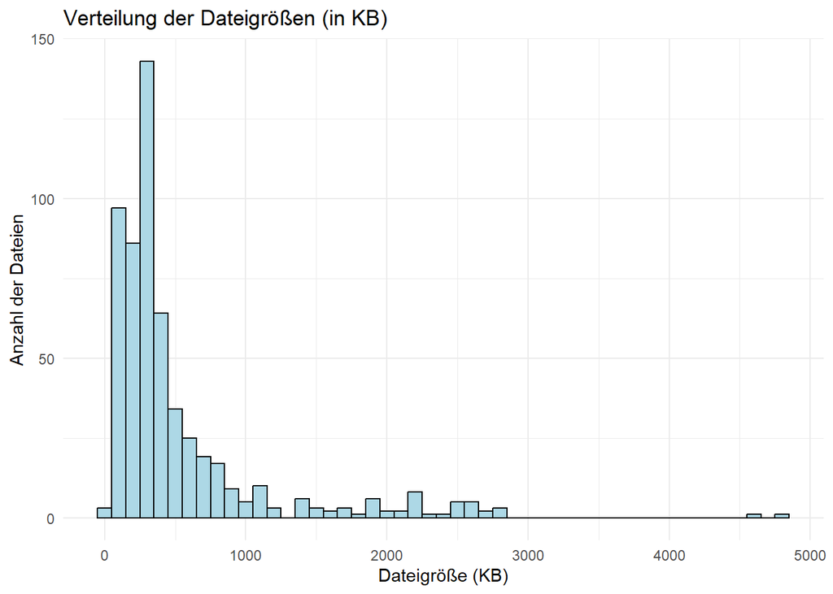

```r
# Histogramm der Verteilung der Dateigrößen (in KB)
ggplot(data_psp_filesize, aes(x = size_kb)) +
  geom_histogram(binwidth = 100, fill = "lightblue", color = "black") +
  labs(title = "Verteilung der Dateigrößen (in KB)", x = "Dateigröße (KB)", y = "Anzahl der Dateien") +
  theme_minimal()
```

## filesize sum

```r
# Neuen Datensatz erstellen mit der Spalte 'psp' (Nummer aus dem Dateinamen)
data_psp_filesize_sum <- data_psp_filesize %>%
  # Extrahiere die Nummer aus dem Dateinamen
  mutate(psp = gsub("\\D", "", name)) %>%
  group_by(psp) %>%
  summarise(
    # Summe der Dateigrößen für das gesamte Paar (Prereg und Publikation)
    size_kb_sum = sum(size_kb),

    # Größe der Prereg-Datei extrahieren
    size_kb_prereg = sum(size_kb[grepl("Prereg.pdf", name)]),

    # Größe der Publikationsdatei (nicht "Prereg.pdf") extrahieren
    size_kb_pubstud = sum(size_kb[!grepl("Prereg.pdf", name)])
  )

# Ergebnis anzeigen
print(data_psp_filesize_sum)
```

```
## # A tibble: 288 × 4
##    psp   size_kb_sum size_kb_prereg size_kb_pubstud
##    <chr>       <dbl>          <dbl>           <dbl>
##  1 100          558.          319.             239.
##  2 104          773.          200.             574.
##  3 105          346.           79.2            267.
##  4 106          367.          123.             244.
##  5 114         1187.          145.            1043.
##  6 115         1181.          125.            1057.
##  7 116         1182.          126.            1057.
##  8 117         1180.          124.            1057.
##  9 118          495.            0              495.
## 10 119         1889.          308.            1581.
## # ℹ 278 more rows
```

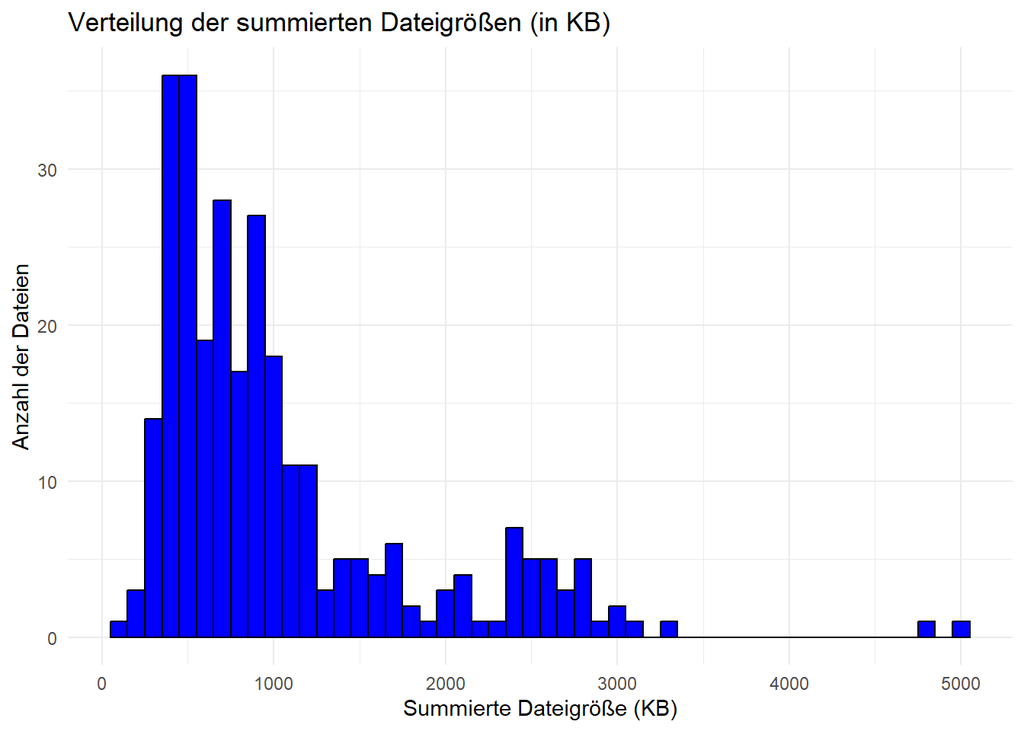

```r
# Histogramm der summierten Dateigrößen (in KB)
ggplot(data_psp_filesize_sum, aes(x = size_kb_sum)) +
  geom_histogram(binwidth = 100, fill = "blue", color = "black") +
  labs(title = "Verteilung der summierten Dateigrößen (in KB)", x = "Summierte Dateigröße (KB)", y = "Anzahl der Dateien") +
  theme_minimal()
```

## merge file size to the processed tatasets.

```r
# Umwandeln der 'psp'-Spalte in data_psp_filesize_sum in numerisch (double), um sie mit den anderen Datensätzen kompatibel zu machen
data_psp_filesize_sum <- data_psp_filesize_sum %>%
  mutate(psp = as.numeric(psp))

# Left Join des Datensatzes data_psp_filesize_sum mit comparison_data_processed
comparison_data_processed <- comparison_data_processed %>%
  left_join(data_psp_filesize_sum, by = "psp")

# Left Join des Datensatzes data_psp_filesize_sum mit data_gpt_olmo_processed
data_gpt_olmo_processed <- data_gpt_olmo_processed %>%
  left_join(data_psp_filesize_sum, by = "psp")

# Left Join des Datensatzes data_psp_filesize_sum mit data_gpt_ve_merged
data_gpt_ve_merged <- data_gpt_ve_merged %>%
  left_join(data_psp_filesize_sum, by = "psp")

# Optional: Anzeigen der Ergebnisse (hier ein Beispiel für die Ausgabe)
head(comparison_data_processed)
```

```
## # A tibble: 6 × 131
##     psp title_pap       study_pap date_gpt            prompt_version test_retest
##   <dbl> <chr>           <chr>     <dttm>              <chr>          <chr>
## 1    16 A Review of Be… NA        2024-06-25 00:00:00 A              Test
## 2    17 Accuracy and c… Study 2   2024-06-26 00:00:00 A              Test
## 3    18 Action Fluency… Experime… 2024-06-26 00:00:00 A              Test
## 4    23 Are tearful in… Study 1   2024-06-26 00:00:00 A              Test
## 5    24 Are tearful in… Study 2   2024-06-26 00:00:00 A              Test
## 6    27 Better calibra… Experime… 2024-06-26 00:00:00 A              Test
## # ℹ 125 more variables: chat_gpt_version <chr>, time_extraction <dbl>,
## #   time_comparison <dbl>, master_exclude <chr>, pre_pre_mi1_comp <named list>,
## #   pre_mi1_comp <named list>, pre_iv1_comp <named list>,
## #   c_pre_iv1_comp <named list>, pre_niv1_1_comp <named list>,
## #   pre_niv1_2_comp <named list>, pre_pre_mi2_comp <named list>,
## #   pre_mi2_comp <named list>, pre_iv2_comp <named list>,
## #   c_pre_iv2_comp <named list>, pre_niv2_1_comp <named list>, …
```

```r
head(data_gpt_olmo_processed)
```

```
## # A tibble: 6 × 300
##     psp title_pap       study_pap date_gpt            prompt_version test_retest
##   <dbl> <chr>           <chr>     <dttm>              <chr>          <chr>
## 1    16 A Review of Be… NA        2024-06-25 00:00:00 A              Test
## 2    17 Accuracy and c… Study 2   2024-06-26 00:00:00 A              Test
## 3    18 Action Fluency… Experime… 2024-06-26 00:00:00 A              Test
## 4    23 Are tearful in… Study 1   2024-06-26 00:00:00 A              Test
## 5    24 Are tearful in… Study 2   2024-06-26 00:00:00 A              Test
## 6    27 Better calibra… Experime… 2024-06-26 00:00:00 A              Test
## # ℹ 294 more variables: chat_gpt_version <chr>, time_extraction <dbl>,
## #   time_comparison <dbl>, pre_pre_mi1_gpt <chr>, pre_mi1_gpt <chr>,
## #   pre_iv1_gpt <chr>, c_pre_iv1_gpt <chr>, pre_niv1_1_gpt <chr>,
## #   pre_niv1_2_gpt <chr>, pre_pre_mi2_gpt <chr>, pre_mi2_gpt <chr>,
## #   pre_iv2_gpt <chr>, c_pre_iv2_gpt <chr>, pre_niv2_1_gpt <chr>,
## #   pre_niv2_2_gpt <chr>, pre_pre_mt_gpt <chr>, pre_mt_gpt <chr>,
## #   pre_tv_gpt <chr>, c_pre_tv_gpt <chr>, pre_ntv_1_gpt <chr>, …
```

```r
head(data_gpt_ve_merged)
```

```
## # A tibble: 6 × 29
##     psp title_pap       study_pap date_gpt            prompt_version test_retest
##   <dbl> <chr>           <chr>     <dttm>              <chr>          <chr>
## 1   411 The power of m… Study 2   2024-09-30 00:00:00 E              Test
## 2   412 The Primacy Ef… Experime… 2024-09-30 00:00:00 E              Test
## 3   413 The Primacy Ef… Experime… 2024-09-30 00:00:00 E              Test
## 4   417 The relative c… NA        2024-09-30 00:00:00 E              Test
## 5   418 The role of em… Study 2   2024-09-30 00:00:00 E              Test
## 6   419 The Role of Ex… Experime… 2024-09-30 00:00:00 E              Test
## # ℹ 23 more variables: deviation_text_new <chr>, master_exclude <chr>,
## #   match_dv_0_gpt <chr>, match_dv_1_gpt <chr>, match_dv_2_gpt <chr>,
## #   match_dv_3_gpt <chr>, match_dcp_1_gpt <chr>, match_dcp_2_gpt <chr>,
## #   match_sm_1_gpt <chr>, match_sm_2_gpt <chr>, match_sm_3_gpt <chr>,
## #   match_dv_0_olmo <chr>, match_dv_1_olmo <chr>, match_dv_2_olmo <chr>,
## #   match_dv_3_olmo <chr>, match_dcp_1_olmo <chr>, match_dcp_2_olmo <chr>,
## #   match_sm_1_olmo <chr>, match_sm_2_olmo <chr>, match_sm_3_olmo <chr>, …
```

# Write to disk

```r
# save data to disk in that dir


write.xlsx(comparison_data_processed, "../Data/processed/comparison_data_processed.xlsx")



write.xlsx(data_gpt_olmo_processed, "../Data/processed/data_gpt_olmo_processed.xlsx")


write.xlsx(data_gpt_ve_merged, "../Data/processed/data_gpt_ve_processed.xlsx")
```